# Proyecto3_Modelación

José Prince, Andre Jo y Nelson Escalante

2025-05-18

## Modelado de datos

Para el análisis del dataset de divorcios se tiene planeado usar como variable respuesta la **diferencia de escolaridad entre hombres y mujeres**. Predecir la escolaridad entre hombre y mujer resulta interesante porque permite explorar desigualdades educativas dentro de las parejas, lo cual puede estar relacionado con factores sociocultirales, económicos o regionales. Esta variable puede reflejar patrones de acceso deigual a la educación por género.

Para la predicción de la variable respuesta se omitieron los valores NA’s presentes en las variables EDADHOM, EDADMUJ, ESCHOM Y ESCMUJ debido a que cambian su valor podia afectar a la predicción de la variable respuesta y es por eso que la dedcisión que se tomo fue removerlas del dataset. De igual forma una variable que se removio debido a su baja correlación la varible respuesta fue CIUOHOM y CIUOMUJ, estas variabes presentaban la ocupación laboral pero se prefirio eliminarla porque en la mayoria de casos la ocupación era desconocida haciendo que no presentara información relevante para los modelos que se realizarán más adelante.

El dataset se dividio en 70 - 30, 70% de los datos son usados para el entrenamiento de los modelos mientras que el 30% restante se usa para probar el dataset.

```
## Distribución en entrenamiento:
```

```
##
## Diferencia moderada    Mucha diferencia     Poca diferencia      Sin diferencia
##          4.85083877          0.03718701         44.25254111         50.85943310
```

```
##
##
## Distribución en prueba:
```

```
##
## Diferencia moderada    Mucha diferencia     Poca diferencia      Sin diferencia
##         4.627398053         0.009640413        44.490504194        50.872457341
```

```
## [1] Sin diferencia Sin diferencia Sin diferencia Sin diferencia Sin diferencia
## [6] Sin diferencia
## 4 Levels: Diferencia moderada Mucha diferencia ... Sin diferencia
```

```
## Confusion Matrix and Statistics
##
##                      Reference
## Prediction            Diferencia moderada Mucha diferencia Poca diferencia
##   Diferencia moderada                   0                0               0
##   Mucha diferencia                      0                1               0
##   Poca diferencia                      58                0            1171
##   Sin diferencia                      422                0            3444
##                      Reference
## Prediction            Sin diferencia
##   Diferencia moderada             29
##   Mucha diferencia                 0
##   Poca diferencia               1083
##   Sin diferencia                4165
##
## Overall Statistics
##
##                Accuracy : 0.5145
##                  95% CI : (0.5048, 0.5242)
##     No Information Rate : 0.5087
##     P-Value [Acc > NIR] : 0.1213
##
##                   Kappa : 0.0421
##
##  Mcnemar's Test P-Value : NA
##
## Statistics by Class:
##
##                      Class: Diferencia moderada Class: Mucha diferencia
## Sensitivity                            0.000000                1.00e+00
## Specificity                            0.997069                1.00e+00
## Pos Pred Value                         0.000000                1.00e+00
## Neg Pred Value                         0.953596                1.00e+00
## Prevalence                             0.046274                9.64e-05
## Detection Rate                         0.000000                9.64e-05
## Detection Prevalence                   0.002796                9.64e-05
## Balanced Accuracy                      0.498534                1.00e+00
##                      Class: Poca diferencia Class: Sin diferencia
## Sensitivity                          0.2537                0.7893
## Specificity                          0.8018                0.2414
## Pos Pred Value                       0.5065                0.5186
## Neg Pred Value                       0.5728                0.5252
## Prevalence                           0.4449                0.5087
## Detection Rate                       0.1129                0.4015
## Detection Prevalence                 0.2229                0.7742
## Balanced Accuracy                    0.5278                0.5153
```

```
## [1] Sin diferencia Sin diferencia Sin diferencia Sin diferencia Sin diferencia
## [6] Sin diferencia
## 4 Levels: Diferencia moderada Mucha diferencia ... Sin diferencia
```

```
## Confusion Matrix and Statistics
##
##                      Reference
## Prediction            Diferencia moderada Mucha diferencia Poca diferencia
##   Diferencia moderada                   0                0               0
##   Mucha diferencia                      0                1               0
##   Poca diferencia                      58                0            1171
##   Sin diferencia                      422                0            3444
##                      Reference
## Prediction            Sin diferencia
##   Diferencia moderada             29
##   Mucha diferencia                 0
##   Poca diferencia               1083
##   Sin diferencia                4165
##
## Overall Statistics
##
##                Accuracy : 0.5145
##                  95% CI : (0.5048, 0.5242)
##     No Information Rate : 0.5087
##     P-Value [Acc > NIR] : 0.1213
##
##                   Kappa : 0.0421
##
##  Mcnemar's Test P-Value : NA
##
## Statistics by Class:
##
##                      Class: Diferencia moderada Class: Mucha diferencia
## Sensitivity                            0.000000                1.00e+00
## Specificity                            0.997069                1.00e+00
## Pos Pred Value                         0.000000                1.00e+00
## Neg Pred Value                         0.953596                1.00e+00
## Prevalence                             0.046274                9.64e-05
## Detection Rate                         0.000000                9.64e-05
## Detection Prevalence                   0.002796                9.64e-05
## Balanced Accuracy                      0.498534                1.00e+00
##                      Class: Poca diferencia Class: Sin diferencia
## Sensitivity                          0.2537                0.7893
## Specificity                          0.8018                0.2414
## Pos Pred Value                       0.5065                0.5186
## Neg Pred Value                       0.5728                0.5252
## Prevalence                           0.4449                0.5087
## Detection Rate                       0.1129                0.4015
## Detection Prevalence                 0.2229                0.7742
## Balanced Accuracy                    0.5278                0.5153
```

```
## [1] Sin diferencia Sin diferencia Sin diferencia Sin diferencia Sin diferencia
## [6] Sin diferencia
## 4 Levels: Diferencia moderada Mucha diferencia ... Sin diferencia
```

```
## Confusion Matrix and Statistics
##
##                      Reference
## Prediction            Diferencia moderada Mucha diferencia Poca diferencia
##   Diferencia moderada                   0                0               0
##   Mucha diferencia                      0                1               0
##   Poca diferencia                      58                0            1171
##   Sin diferencia                      422                0            3444
##                      Reference
## Prediction            Sin diferencia
##   Diferencia moderada             29
##   Mucha diferencia                 0
##   Poca diferencia               1084
##   Sin diferencia                4164
##
## Overall Statistics
##
##                Accuracy : 0.5144
##                  95% CI : (0.5047, 0.5241)
##     No Information Rate : 0.5087
##     P-Value [Acc > NIR] : 0.1253
##
##                   Kappa : 0.0419
##
##  Mcnemar's Test P-Value : NA
##
## Statistics by Class:
##
##                      Class: Diferencia moderada Class: Mucha diferencia
## Sensitivity                            0.000000                1.00e+00
## Specificity                            0.997069                1.00e+00
## Pos Pred Value                         0.000000                1.00e+00
## Neg Pred Value                         0.953596                1.00e+00
## Prevalence                             0.046274                9.64e-05
## Detection Rate                         0.000000                9.64e-05
## Detection Prevalence                   0.002796                9.64e-05
## Balanced Accuracy                      0.498534                1.00e+00
##                      Class: Poca diferencia Class: Sin diferencia
## Sensitivity                          0.2537                0.7891
## Specificity                          0.8017                0.2414
## Pos Pred Value                       0.5063                0.5186
## Neg Pred Value                       0.5727                0.5250
## Prevalence                           0.4449                0.5087
## Detection Rate                       0.1129                0.4014
## Detection Prevalence                 0.2230                0.7741
## Balanced Accuracy                    0.5277                0.5152
```

```
## Confusion Matrix and Statistics
##
##                      Reference
## Prediction            Diferencia moderada Mucha diferencia Poca diferencia
##   Diferencia moderada                 464                1               0
##   Mucha diferencia                      0                0               0
##   Poca diferencia                      16                0            4598
##   Sin diferencia                        0                0              17
##                      Reference
## Prediction            Sin diferencia
##   Diferencia moderada              0
##   Mucha diferencia                 0
##   Poca diferencia                  1
##   Sin diferencia                5276
##
## Overall Statistics
##
##                Accuracy : 0.9966
##                  95% CI : (0.9953, 0.9976)
##     No Information Rate : 0.5087
##     P-Value [Acc > NIR] : < 2.2e-16
##
##                   Kappa : 0.9938
##
##  Mcnemar's Test P-Value : NA
##
## Statistics by Class:
##
##                      Class: Diferencia moderada Class: Mucha diferencia
## Sensitivity                             0.96667               0.0000000
## Specificity                             0.99990               1.0000000
## Pos Pred Value                          0.99785                     NaN
## Neg Pred Value                          0.99839               0.9999036
## Prevalence                              0.04627               0.0000964
## Detection Rate                          0.04473               0.0000000
## Detection Prevalence                    0.04483               0.0000000
## Balanced Accuracy                       0.98328               0.5000000
##                      Class: Poca diferencia Class: Sin diferencia
## Sensitivity                          0.9963                0.9998
## Specificity                          0.9970                0.9967
## Pos Pred Value                       0.9963                0.9968
## Neg Pred Value                       0.9970                0.9998
## Prevalence                           0.4449                0.5087
## Detection Rate                       0.4433                0.5086
## Detection Prevalence                 0.4449                0.5103
## Balanced Accuracy                    0.9967                0.9982
```

```
## Confusion Matrix and Statistics
##
##                      Reference
## Prediction            Diferencia moderada Mucha diferencia Poca diferencia
##   Diferencia moderada                 465                1               0
##   Mucha diferencia                      0                0               0
##   Poca diferencia                      15                0            4597
##   Sin diferencia                        0                0              18
##                      Reference
## Prediction            Sin diferencia
##   Diferencia moderada              0
##   Mucha diferencia                 0
##   Poca diferencia                  0
##   Sin diferencia                5277
##
## Overall Statistics
##
##                Accuracy : 0.9967
##                  95% CI : (0.9954, 0.9977)
##     No Information Rate : 0.5087
##     P-Value [Acc > NIR] : < 2.2e-16
##
##                   Kappa : 0.9939
##
##  Mcnemar's Test P-Value : NA
##
## Statistics by Class:
##
##                      Class: Diferencia moderada Class: Mucha diferencia
## Sensitivity                             0.96875               0.0000000
## Specificity                             0.99990               1.0000000
## Pos Pred Value                          0.99785                     NaN
## Neg Pred Value                          0.99849               0.9999036
## Prevalence                              0.04627               0.0000964
## Detection Rate                          0.04483               0.0000000
## Detection Prevalence                    0.04492               0.0000000
## Balanced Accuracy                       0.98432               0.5000000
##                      Class: Poca diferencia Class: Sin diferencia
## Sensitivity                          0.9961                1.0000
## Specificity                          0.9974                0.9965
## Pos Pred Value                       0.9967                0.9966
## Neg Pred Value                       0.9969                1.0000
## Prevalence                           0.4449                0.5087
## Detection Rate                       0.4432                0.5087
## Detection Prevalence                 0.4446                0.5105
## Balanced Accuracy                    0.9967                0.9982
```

```
## Confusion Matrix and Statistics
##
##                      Reference
## Prediction            Diferencia moderada Mucha diferencia Poca diferencia
##   Diferencia moderada                 470                1               0
##   Mucha diferencia                      0                0               0
##   Poca diferencia                      10                0            4614
##   Sin diferencia                        0                0               1
##                      Reference
## Prediction            Sin diferencia
##   Diferencia moderada              0
##   Mucha diferencia                 0
##   Poca diferencia                  0
##   Sin diferencia                5277
##
## Overall Statistics
##
##                Accuracy : 0.9988
##                  95% CI : (0.998, 0.9994)
##     No Information Rate : 0.5087
##     P-Value [Acc > NIR] : < 2.2e-16
##
##                   Kappa : 0.9979
##
##  Mcnemar's Test P-Value : NA
##
## Statistics by Class:
##
##                      Class: Diferencia moderada Class: Mucha diferencia
## Sensitivity                             0.97917               0.0000000
## Specificity                             0.99990               1.0000000
## Pos Pred Value                          0.99788                     NaN
## Neg Pred Value                          0.99899               0.9999036
## Prevalence                              0.04627               0.0000964
## Detection Rate                          0.04531               0.0000000
## Detection Prevalence                    0.04541               0.0000000
## Balanced Accuracy                       0.98953               0.5000000
##                      Class: Poca diferencia Class: Sin diferencia
## Sensitivity                          0.9998                1.0000
## Specificity                          0.9983                0.9998
## Pos Pred Value                       0.9978                0.9998
## Neg Pred Value                       0.9998                1.0000
## Prevalence                           0.4449                0.5087
## Detection Rate                       0.4448                0.5087
## Detection Prevalence                 0.4458                0.5088
## Balanced Accuracy                    0.9990                0.9999
```

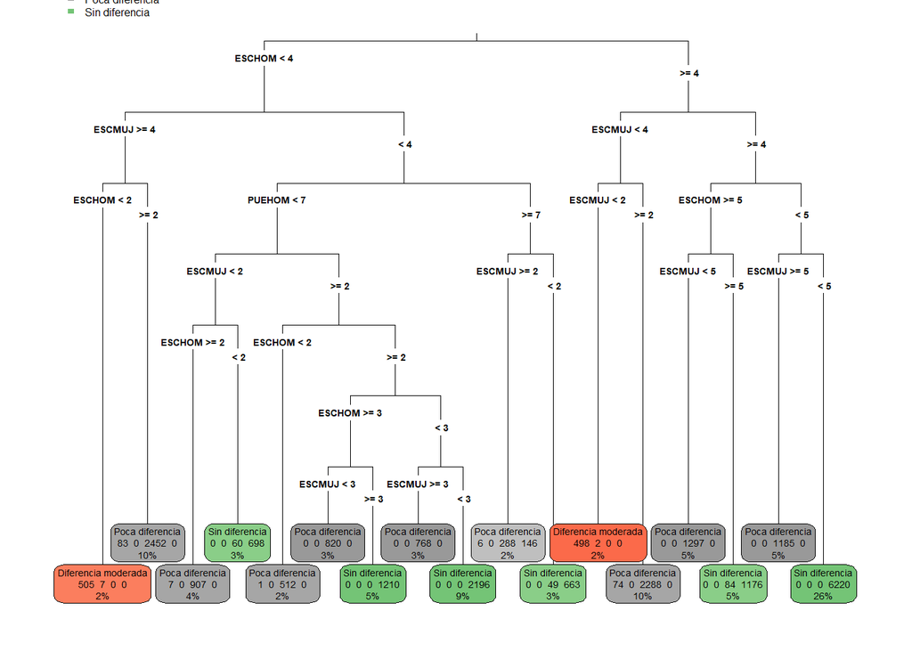

```
## Confusion Matrix and Statistics
##
##                      Reference
## Prediction            Diferencia moderada Mucha diferencia Poca diferencia
##   Diferencia moderada                 421                1               0
##   Mucha diferencia                      0                0               0
##   Poca diferencia                      59                0            4532
##   Sin diferencia                        0                0              83
##                      Reference
## Prediction            Sin diferencia
##   Diferencia moderada              0
##   Mucha diferencia                 0
##   Poca diferencia                 60
##   Sin diferencia                5217
##
## Overall Statistics
##
##                Accuracy : 0.9804
##                  95% CI : (0.9776, 0.983)
##     No Information Rate : 0.5087
##     P-Value [Acc > NIR] : < 2.2e-16
##
##                   Kappa : 0.9637
##
##  Mcnemar's Test P-Value : NA
##
## Statistics by Class:
##
##                      Class: Diferencia moderada Class: Mucha diferencia
## Sensitivity                             0.87708               0.0000000
## Specificity                             0.99990               1.0000000
## Pos Pred Value                          0.99763                     NaN
## Neg Pred Value                          0.99407               0.9999036
## Prevalence                              0.04627               0.0000964
## Detection Rate                          0.04059               0.0000000
## Detection Prevalence                    0.04068               0.0000000
## Balanced Accuracy                       0.93849               0.5000000
##                      Class: Poca diferencia Class: Sin diferencia
## Sensitivity                          0.9820                0.9886
## Specificity                          0.9793                0.9837
## Pos Pred Value                       0.9744                0.9843
## Neg Pred Value                       0.9855                0.9882
## Prevalence                           0.4449                0.5087
## Detection Rate                       0.4369                0.5029
## Detection Prevalence                 0.4484                0.5109
## Balanced Accuracy                    0.9807                0.9862
```

```
##      cp
## 1 0.001
```

```
## Confusion Matrix and Statistics
##
##                      Reference
## Prediction            Diferencia moderada Mucha diferencia Poca diferencia
##   Diferencia moderada                 421                1               0
##   Mucha diferencia                      0                0               0
##   Poca diferencia                      59                0            4532
##   Sin diferencia                        0                0              83
##                      Reference
## Prediction            Sin diferencia
##   Diferencia moderada              0
##   Mucha diferencia                 0
##   Poca diferencia                 60
##   Sin diferencia                5217
##
## Overall Statistics
##
##                Accuracy : 0.9804
##                  95% CI : (0.9776, 0.983)
##     No Information Rate : 0.5087
##     P-Value [Acc > NIR] : < 2.2e-16
##
##                   Kappa : 0.9637
##
##  Mcnemar's Test P-Value : NA
##
## Statistics by Class:
##
##                      Class: Diferencia moderada Class: Mucha diferencia
## Sensitivity                             0.87708               0.0000000
## Specificity                             0.99990               1.0000000
## Pos Pred Value                          0.99763                     NaN
## Neg Pred Value                          0.99407               0.9999036
## Prevalence                              0.04627               0.0000964
## Detection Rate                          0.04059               0.0000000
## Detection Prevalence                    0.04068               0.0000000
## Balanced Accuracy                       0.93849               0.5000000
##                      Class: Poca diferencia Class: Sin diferencia
## Sensitivity                          0.9820                0.9886
## Specificity                          0.9793                0.9837
## Pos Pred Value                       0.9744                0.9843
## Neg Pred Value                       0.9855                0.9882
## Prevalence                           0.4449                0.5087
## Detection Rate                       0.4369                0.5029
## Detection Prevalence                 0.4484                0.5109
## Balanced Accuracy                    0.9807                0.9862
```

```
## Confusion Matrix and Statistics
##
##                      Reference
## Prediction            Diferencia moderada Mucha diferencia Poca diferencia
##   Diferencia moderada                 470                1               0
##   Mucha diferencia                      0                0               0
##   Poca diferencia                      10                0            4580
##   Sin diferencia                        0                0              35
##                      Reference
## Prediction            Sin diferencia
##   Diferencia moderada              0
##   Mucha diferencia                 0
##   Poca diferencia                  1
##   Sin diferencia                5276
##
## Overall Statistics
##
##                Accuracy : 0.9955
##                  95% CI : (0.994, 0.9967)
##     No Information Rate : 0.5087
##     P-Value [Acc > NIR] : < 2.2e-16
##
##                   Kappa : 0.9916
##
##  Mcnemar's Test P-Value : NA
##
## Statistics by Class:
##
##                      Class: Diferencia moderada Class: Mucha diferencia
## Sensitivity                             0.97917               0.0000000
## Specificity                             0.99990               1.0000000
## Pos Pred Value                          0.99788                     NaN
## Neg Pred Value                          0.99899               0.9999036
## Prevalence                              0.04627               0.0000964
## Detection Rate                          0.04531               0.0000000
## Detection Prevalence                    0.04541               0.0000000
## Balanced Accuracy                       0.98953               0.5000000
##                      Class: Poca diferencia Class: Sin diferencia
## Sensitivity                          0.9924                0.9998
## Specificity                          0.9981                0.9931
## Pos Pred Value                       0.9976                0.9934
## Neg Pred Value                       0.9939                0.9998
## Prevalence                           0.4449                0.5087
## Detection Rate                       0.4415                0.5086
## Detection Prevalence                 0.4426                0.5120
## Balanced Accuracy                    0.9953                0.9965
```

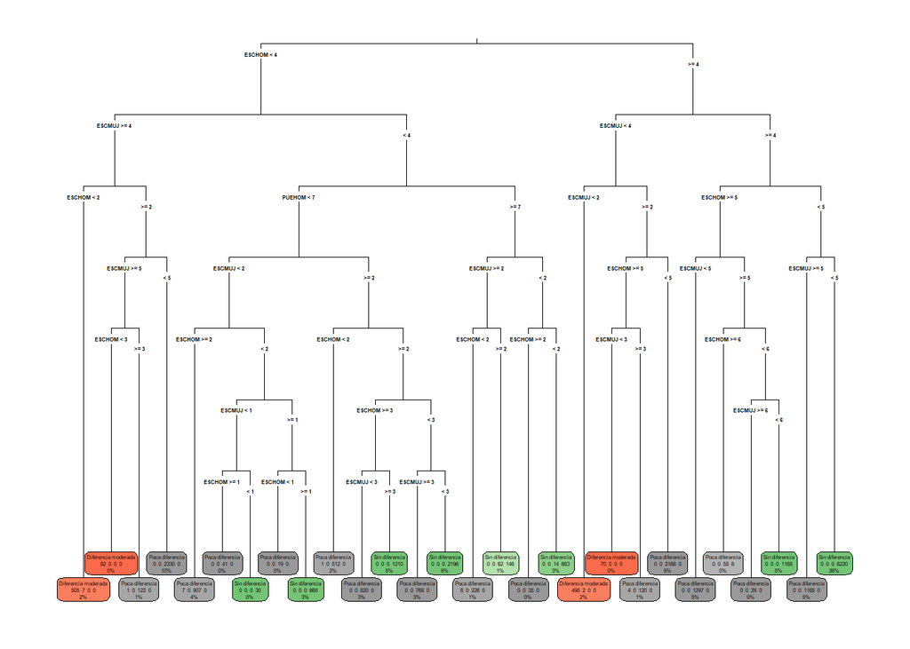

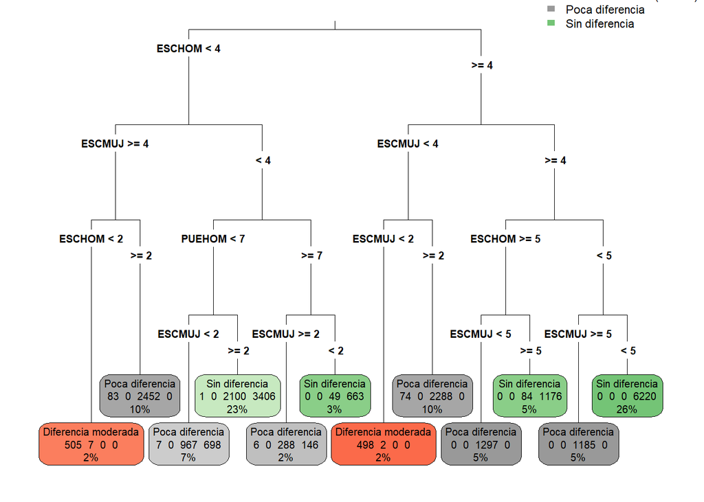

```
## Confusion Matrix and Statistics
##
##                      Reference
## Prediction            Diferencia moderada Mucha diferencia Poca diferencia
##   Diferencia moderada                 421                1               0
##   Mucha diferencia                      0                0               0
##   Poca diferencia                      58                0            3588
##   Sin diferencia                        1                0            1027
##                      Reference
## Prediction            Sin diferencia
##   Diferencia moderada              0
##   Mucha diferencia                 0
##   Poca diferencia                342
##   Sin diferencia                4935
##
## Overall Statistics
##
##                Accuracy : 0.8622
##                  95% CI : (0.8555, 0.8688)
##     No Information Rate : 0.5087
##     P-Value [Acc > NIR] : < 2.2e-16
##
##                   Kappa : 0.7423
##
##  Mcnemar's Test P-Value : NA
##
## Statistics by Class:
##
##                      Class: Diferencia moderada Class: Mucha diferencia
## Sensitivity                             0.87708               0.0000000
## Specificity                             0.99990               1.0000000
## Pos Pred Value                          0.99763                     NaN
## Neg Pred Value                          0.99407               0.9999036
## Prevalence                              0.04627               0.0000964
## Detection Rate                          0.04059               0.0000000
## Detection Prevalence                    0.04068               0.0000000
## Balanced Accuracy                       0.93849               0.5000000
##                      Class: Poca diferencia Class: Sin diferencia
## Sensitivity                          0.7775                0.9352
## Specificity                          0.9305                0.7983
## Pos Pred Value                       0.8997                0.8276
## Neg Pred Value                       0.8392                0.9224
## Prevalence                           0.4449                0.5087
## Detection Rate                       0.3459                0.4758
## Detection Prevalence                 0.3845                0.5749
## Balanced Accuracy                    0.8540                0.8667
```

En base a la variable objetivo (ESCDIFFERENCE), la cual es una variable categórica, el problema fue abordado como un problema de clasificación. Se utilizaron matrices de confusión para analizar el desempeño de cada uno de los algoritmos utilizados. Los modelos fueron entrenados con una división 70-30 de los datos, entre entrenamiento y prueba respectivamente. En todos los casos, los modelos tuvieron mejor precisión en las clases mas frecuentes (“Poca diferencia” y “Sin diferencia”).

Se realizó una regresión logística multinomial (multinom) con variantes de validación cruzada (10-fold y 1-fold) y con ajustes del hiperparámetro decay. Se observó que era mejor cuando tenía un decay cercano a 0.01. El modelo tuvo un desempeño aceptable, con un accuracy de ~0.51 en la predicción total de los datos, pero no fue tan bueno como los otros dos modelos realizados.

El segundo mejor modelo realizado fueron los árboles de decisión. Se incluyó visualización de los modelos, lo que es útil para entender las relaciones entre las variables y las reglas de decisión. El modelo fue bastante bueno, mostrando una alta accuracy en las predicciones, aunque tampoco llegó a ser tan bueno como el mejor modelo analizado.